[figure not shown]

# Análise sobre os atendimentos da PMSC

## Município de Criciúma

Objetivo específico desta análise:

- Observar o volume das ocorrências ao longo do tempo
- Compreender como as ocorrências são reportadas e quais geram atendimentos
- Verificar o tempo médio, e o volume de tempo investido pela PM em cada classificação de atendimento

[Página anterior](https://igarape-inc.github.io/asc/intro.html) | [Página inicial](https://igarape-inc.github.io/asc/intro.html) | [Próxima página](https://igarape-inc.github.io/asc/analise_ocorrencias_floripa.html)

## Origem dos registros das ocorrências

Uma ocorrência pode ter as seguintes origens registradas no banco de dados:

- Telefone (cidadão informou via telefone 190)
- Direto à guarnição (cidadão informou direto à guarnição)
- Guarnição se deparou
- Videomonitoramento (câmeras de videomonitoramento)
- 190 acessível (aplicativo da PMSC para pessoas com deficiência autidiva)

A próxima tabela indica a proporção de registros relativos a cada código de origem:

```
Total de ocorrências no período: 629804
```

|  | Descrição | contagem | % |
| --- | --- | --- | --- |
| 0 | Telefone | 598059 | 97.18 |
| 1 | Guarnição se deparou | 11101 | 1.80 |
| 2 | Direto à guarnição | 5984 | 0.97 |
| 3 | Videomonitoramento | 203 | 0.03 |
| 4 | 190 acessível | 97 | 0.02 |

## Categorias de chamadas ao 190

A tabela abaixo demonstra a proporção de chamadas ao 190, por categoria.

A categoria de cada chamada é definida pelo atendente do COPOM. Existem sete opções de categorias.

```
Total de chamadas ao 190 - jan/2016 a maio/2019 587424
```

| ID | categoria | contagem | % |
| --- | --- | --- | --- |
| 11 | Ligação interrompida | 294257 | 50.09 |
| 1 | Ocorrência | 187859 | 31.98 |
| 6 | Informação | 84968 | 14.46 |
| 7 | Trote | 16181 | 2.75 |
| 10 | Engano | 3638 | 0.62 |
| 8 | Elogio | 280 | 0.05 |
| 5 | Denúncia | 241 | 0.04 |

```
n_total = 587424
```

[interactive chart not shown]

## Ligações interrompidas que geraram atendimento

A seguir temos todas as ocorrências registradas com:

- ID_CATEGORIA registrado como *Ligação interrompida* (código 11), e
- ID_GUARNICAO não-nulo

Em Criciúma, foram apenas duas ocorrências com ligação interrompida que geraram atendimento desde 2016.

|  | ID_ATENDIMENTO | ID_CATEGORIA | DATA_HORA_FATO | classificação atendimento | ID_CODIGO_FECHAMENTO |
| --- | --- | --- | --- | --- | --- |
| 23358 | 5007480835.00 | 11.00 | 2017-12-10 00:40:23 | Averiguação de veículo suspeito | 10.00 |
| 210750 | 5005069097.00 | 11.00 | 2016-06-22 20:16:28 | Inválido | 21.00 |

## Volume de *atendimentos* por classificação de atendimento - 2018

No gráfico abaixo, verificam-se os registros que geraram atendimento policial:

- Registros que tiveram ID_ATENDIMENTO_UNIDADE (ou seja que este campo na base de dados não consta como nulo); e
- que *não tiveram* código de fechamento CF16 - Falta de Patrulha

O gráfico apresenta as 50 classificações de atendimento mais atendidas pela PM em 2018.

*Clique e arraste o gráfico para dar zoom e ver o nome completo da classificação de atendimento. Duplo-clique para retornar ao zoom original.*

```
Total de antendimentos em 2018 = 150746
```

[interactive chart not shown]

## Volume diário de ocorrências registradas

O gráfico a seguir apresenta o volume diário de todos as ocorrências registradas.

*Clique e arraste no gráfico para dar zoom. Clique duas vezes em qualquer ponto do gráfico para voltar ao zoom original.*

```
TOTAL DE OCORRÊNCIAS ENTRE 1/JAN/2016 E 28/MAIO/2019:
629804
```

[interactive chart not shown]

```
TOTAL DE OCORRÊNCIAS INVÁLIDAS ENTRE 1/JAN/2016 E 28/MAIO/2019:
404310
```

[interactive chart not shown]

```
TOTAL DE OCORRÊNCIAS VÁLIDAS ENTRE 1/JAN/2016 E 28/MAIO/2019:
225494
```

[interactive chart not shown]

## Origem e desfecho das ocorrências inválidas - ano de 2018

São consideradas inválidas as ocorrências que tiveram:

- ID_TIPO_ATENDIMENTO inválido (código 42), ou
- ID_CODIGO_FECHAMENTO inválido (código 24), ou
- ID_CLASSIFICACAO_ATENDIMENTO inválido (código 1293)

```
Origem das ocorrências inválidas - 2018
n° total de ocorrências = 84527
```

| Descrição | contagem | % |
| --- | --- | --- |
| Telefone | 80376 | 95.09 |
| Registro nulo | 4067 | 4.81 |
| Guarnição se deparou | 53 | 0.06 |
| Direto à guarnição | 31 | 0.04 |

```
ID_CATEGORIA das ocorrências inválidas - 2018
n° total de ocorrências = 84527
```

| ID | categoria | contagem | % |
| --- | --- | --- | --- |
| 11 | Ligação interrompida | 48957 | 57.92 |
| 6 | Informação | 23555 | 27.87 |
| 7 | Trote | 8425 | 9.97 |
| 10 | Engano | 2297 | 2.72 |
| 1 | Ocorrência | 1222 | 1.45 |
| 8 | Elogio | 70 | 0.08 |
| 5 | Denúncia | 1 | 0.00 |

```
Classificação de atendimento das ocorrências inválidas - 2018
n° total de ocorrências = 84527
```

|  | ID | contagem | % | classificação atendimento |
| --- | --- | --- | --- | --- |
| 0 | 1293.0 | 84527 | 100.00 | Inválido |

```
Código de fechamento das ocorrências inválidas - 2018
n° total de ocorrências = 84527
```

| Descrição | contagem | % |
| --- | --- | --- |
| Inválido | 83308 | 98.56 |
| Ocorrência duplicada | 1216 | 1.44 |
| Atendimento dispensado pelo solicitante | 1 | 0.00 |
| Atendimento encerrado automaticamente após 48 horas de sua criação | 1 | 0.00 |
| BO-AT: Acidente de Trânsito | 1 | 0.00 |

## Ocorrências inválidas que tiveram atendimento

São contabilizadas, à seguir, as ocorrências inválidas que tiveram atendimento de alguma guarnição - ou seja, ocorrências com ID_CLASSIFICACAO_ATENDIMENTO inválido e ID_GUARNICAO não-nulo.

```
n° total de ocorrências inválidas que tiveram atendimento em 2018 = 295
```

```
ID_CATEGORIA das ocorrências inválidas que tiveram atendimento - 2018
n° total de ocorrências = 295
```

| ID | categoria | contagem | % |
| --- | --- | --- | --- |
| 1 | Ocorrência | 295 | 100.00 |

```
Código de fechamento das ocorrências inválidas  que tiveram atendimento - 2018
n° total de ocorrências = 295
```

| Descrição | contagem | % |
| --- | --- | --- |
| Ocorrência duplicada | 293 | 99.32 |
| BO-AT: Acidente de Trânsito | 1 | 0.34 |
| Inválido | 1 | 0.34 |

## Análise das chamadas sem atendimento

Uma chamada ao 190, mesmo sendo válida, pode não receber o atendimento da polícia.

Na base de dados, uma chamada sem atendimento pode ser registrada de duas maneiras (i) com o ID_ATENDIMENTO_UNIDADE nulo, indicando que não houve despacho pelo COPOM, ou (ii) com o código de fechamento da ocorrência "CF16 - Falta de Patrulha", indicando que houve despacho do COPOM, mas que a Unidade da PM responsável não foi capaz de prestar o atendimento.

**Para certificar-se de que todas as chamadas sem atendimento foram contabilizadas, verificou-se que:**

- Dentre as chamadas com ID_ATENDIMENTO_UNIDADE nulo, nenhuma tem ID_ATENDIMENTO duplicado √
- Quando o ID_ATENDIMENTO_UNIDADE é nulo, o ID_ATENDIMENTO_ENCERRAMENTO também é nulo √
- Quando o ID_ATENDIMENTO_UNIDADE é nulo, o ID_CODIGO_FECHAMENTO também é nulo √
- Todas as chamadas no banco têm ao menos uma classificação de atendimento registrada √

```
Número de chamadas sem ID_ATENDIMENTO:
```

```
0
```

```
Número e porcentagem de chamadas sem ID_ATENDIMENTO_UNIDADE:
23
0.0 %
```

```
Número de chamadas com ID_ATENDIMENTO_UNIDADE nulo, e ID_ATENDIMENTO duplicado:
```

```
0
```

```
Número de chamadas sem ID_ATENDIMENTO_UNIDADE, porém com ID_ATENDIMENTO_ENCERRAMENTO:
```

```
0
```

```
Número de chamadas sem ID_ATENDIMENTO_UNIDADE, porém com ID_CODIGO_FECHAMENTO:
```

```
0
```

```
Numero de chamadas sem classificação de atendimento:
```

```
0
```

**Ocorrências com ID_ATENDIMENTO_UNIDADE nulo**

A tabela a seguir lista todas as ocorrências com ID_ATENDIMENTO registrado, porém sem ID_ATENDIMENTO_UNIDADE (possívelmente indicando que não houve despacho pelo COPOM).

```
Total de ocorrências de jan/2016 a maio/2019: 629804

Total de ocorrências sem ID_ATENDIMENTO UNIDADE: 23
```

|  | ID | contagem | % | classificação atendimento |
| --- | --- | --- | --- | --- |
| 0 | 1293.00 | 15 | 65.22 | Inválido |
| 1 | 159.00 | 2 | 8.70 | Outras averiguações |
| 2 | 63.00 | 1 | 4.35 | Posse de drogas |
| 3 | 158.00 | 1 | 4.35 | Averiguação de pessoa em atitude suspeita |
| 4 | 1955.00 | 1 | 4.35 | Fiscalização de apenado em Regime Aberto |
| 5 | 45.00 | 1 | 4.35 | Assédio sexual |
| 6 | 1835.00 | 1 | 4.35 | Averiguação de veículo suspeito |
| 7 | 114.00 | 1 | 4.35 | Perturbação do trabalho ou sossego alheio |

**Ocorrências com código de fechamento "falta de patrulha"**

A tabela e gráfico abaixo listam as ocorrências que têm registro de um ID_ATENDIMENTO_UNIDADE, porém com o código de fechamento **CF16 - Falta de patrulha**.

```
Número de ocorrências com código de fechamento "Falta de patrulha": 2893

Porcentagem de ocorrências com código de fechamento "Falta de patrulha": 0.49 %
```

|  | ID | contagem | % | classificação atendimento |
| --- | --- | --- | --- | --- |
| 0 | 114.00 | 1577 | 54.51 | Perturbação do trabalho ou sossego alheio |
| 1 | 158.00 | 254 | 8.78 | Averiguação de pessoa em atitude suspeita |
| 2 | 159.00 | 136 | 4.70 | Outras averiguações |
| 3 | 3630.00 | 115 | 3.98 | Perturbação da tranquilidade |
| 4 | 1835.00 | 75 | 2.59 | Averiguação de veículo suspeito |
| 5 | 3631.00 | 74 | 2.56 | Perturbação do trabalho ou sossego alheios |
| 6 | 117.00 | 65 | 2.25 | Atrito verbal ou discussão |
| 7 | 13.00 | 56 | 1.94 | Vias de fato |
| 8 | 63.00 | 54 | 1.87 | Posse de drogas |
| 9 | 1360.00 | 50 | 1.73 | Utilizar-se de veículo para, em via pública, demonstrar ou exibir manobra perigosa |
| 10 | 1341.00 | 43 | 1.49 | Outras Infrações de Trânsito |
| 11 | 25.00 | 34 | 1.18 | Ameaça |
| 12 | 268.00 | 29 | 1.00 | Acidente de trânsito apenas danos materiais |
| 13 | 163.00 | 27 | 0.93 | Animal solto em via pública |
| 14 | 3097.00 | 24 | 0.83 | Averiguação de pessoa em atitude suspeita |

```
Número de ocorrências com código de fechamento "Falta de patrulha": 2893
```

[interactive chart not shown]

```
Número de ocorrências de PERTURBAÇÃO sem atendimento por falta de patrulha: 1766
```

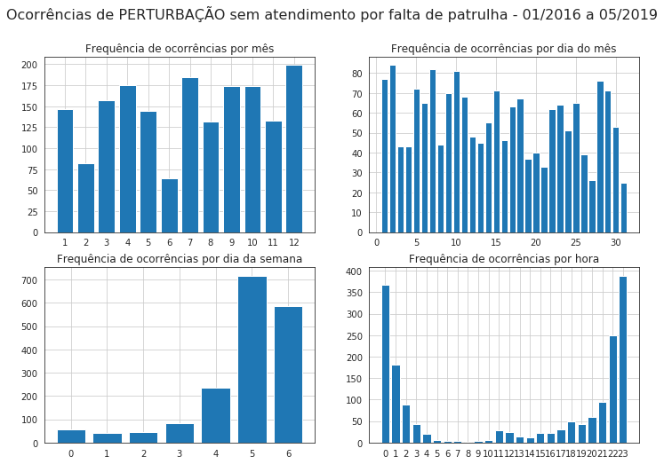

```
Número de ocorrências de (EXCLUINDO PERTURBAÇÃO) sem atendimento por falta de patrulha: 1127
```

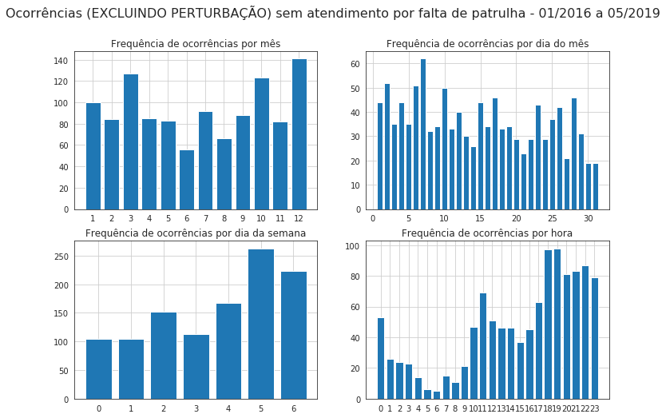

**Ocorrências com código de fechamento "falta de patrulha", por ID_UNIDADE**

A tabela abaixo lista as ocorrências registradas com o código de fechamento **CF16 - Falta de patrulha**, por Unidade da PM.

```
Total de ocorrências com CF16 - 01/2016 a 05/2019: 2893
```

|  | ID_UNIDADE | total de ocorrências da unidade | nº ocorrências CF16 | % CF16 |
| --- | --- | --- | --- | --- |
| 0 | 1310 | 548434 | 2002 | 0.37 |
| 1 | 1347 | 28680 | 235 | 0.82 |
| 2 | 1341 | 13501 | 131 | 0.97 |
| 3 | 1376 | 11765 | 210 | 1.78 |
| 4 | 1371 | 8137 | 84 | 1.03 |
| 5 | 1373 | 7895 | 111 | 1.41 |
| 6 | 2071 | 5327 | 40 | 0.75 |
| 7 | 1342 | 4101 | 25 | 0.61 |
| 8 | 197 | 517 | 12 | 2.32 |
| 9 | 1813 | 377 | 23 | 6.10 |
| 10 | 196 | 347 | 16 | 4.61 |
| 11 | 2371 | 171 | 0 | 0.00 |
| 12 | 1816 | 170 | 4 | 2.35 |
| 13 | 2370 | 170 | 0 | 0.00 |
| 14 | 1190 | 86 | 0 | 0.00 |

## Códigos de fechamento

A PMSC tem uma série de códigos para descrever o fechamento de uma ocorrência. A tabela abaixo indica a proporção de registros relativos a cada código de fechamento.

```
Total de ocorrências no período - 01/2016 a 05/2019: 629804
```

|  | Descrição | ID_CODIGO_FECHAMENTO | contagem | % |
| --- | --- | --- | --- | --- |
| 0 | Inválido | 21 | 399328 | 63.41 |
| 1 | Resolvido no local | 12 | 40089 | 6.37 |
| 2 | Fato sem informações para registro | 14 | 31644 | 5.02 |
| 3 | Comunicação de Ocorrência Policial | 1 | 28108 | 4.46 |
| 4 | Averiguação Policial sem Alteração | 10 | 26114 | 4.15 |
| 5 | Ocorrência Inexistente | 9 | 20100 | 3.19 |
| 6 | Registro de Ocorrência | 8 | 13161 | 2.09 |
| 7 | Prisão/Apreensão | 2 | 12767 | 2.03 |
| 8 | BO-AT: Acidente de Trânsito | 4 | 11858 | 1.88 |
| 9 | Providências Administrativas de Trânsito Adotadas | 11 | 11313 | 1.80 |
| 10 | Termo Circunstanciado | 3 | 8071 | 1.28 |
| 11 | Atendimento dispensado pelo solicitante | 13 | 8045 | 1.28 |
| 12 | Atendimento encaminhado a outros órgãos | 20 | 4663 | 0.74 |
| 13 | Ocorrência duplicada | 15 | 3712 | 0.59 |
| 14 | Falta de patrulha | 16 | 2893 | 0.46 |
| 15 | Atendimento transmitido à Rede de Rádio | 23 | 2630 | 0.42 |
| 16 | Atendimento encaminhado para o BPMRv | 19 | 1851 | 0.29 |
| 17 | BO-AT/TC: Acidente de Trânsito/TC | 5 | 1066 | 0.17 |
| 18 | Atendimento encaminhado para o P2 da OPM | 18 | 952 | 0.15 |
| 19 | BO-AT/COP: Acidente de Trânsito/COP | 7 | 695 | 0.11 |
| 20 | BO-AT/PA: Acidente de Trânsito-Prisão/Apreensão | 6 | 544 | 0.09 |
| 21 | Atendimento encerrado automaticamente após 48 horas de sua criação | 22 | 142 | 0.02 |
| 22 | Atendimento encaminhado para o BPMA | 17 | 19 | 0.00 |

## Averiguações

As ocorrências de averiguação podem ser auto-iniciadas pela guarnição, ou geradas pelo COPOM em resposta aos telefonemas de cidadãos informando atitudes suspeitas.

Uma ocorrência de averiguação pode ser identificada pela sua classificação de atendimento (ex.:, *Averiguação de veículo suspeito*), pelo seu código de fechamento (*CF10 - Averiguação Policial sem Alteração*), ou pelo ID_TIPO_ATENDIMENTO (*ID 11 - Averiguação*).

```
Total de ocorrências de averiguação: 62825

% de averiguações sobre o total de atendimentos: 9.98%
```

|  | ID | classificação atendimento | contagem | % |
| --- | --- | --- | --- | --- |
| 0 | 158 | Averiguação de pessoa em atitude suspeita | 25600 | 40.75 |
| 1 | 159 | Outras averiguações | 11245 | 17.90 |
| 2 | 1835 | Averiguação de veículo suspeito | 9704 | 15.45 |
| 3 | 1836 | Averiguação em residência ou comércio | 8220 | 13.08 |
| 4 | 3099 | Averiguação em residência ou comércio | 2975 | 4.74 |
| 5 | 3097 | Averiguação de pessoa em atitude suspeita | 2093 | 3.33 |
| 6 | 3098 | Averiguação de veículo suspeito | 1411 | 2.25 |
| 7 | 3382 | Fiscalização de apenado em regime aberto | 600 | 0.96 |
| 8 | 160 | Abordagem de veículos em vistoria de trânsito | 522 | 0.83 |
| 9 | 3273 | Encontro ou recuperação de bem/objeto | 240 | 0.38 |

*No gráfico abaixo, clique na legenda para des-selecionar/re-selecionar uma categoria. Clique duas vezes para selecionar só ela.*

[interactive chart not shown]

## Tempo médio de atendimento

O próximo gráfico apresenta o tempo médio de atendimento de classificações de fato que (i) tenham informação disponível sobre a DATA_HORA_CHEGADA e DATA_HORA_FECHAMENTO, e (ii) satisfazendo essas condições, tenham ocorrido ao menos 30 vezes.

**Os dados são de jan/2016 a maio/2019.**

[interactive chart not shown]

## Tempo total de atendimento

O gráfico abaixo apresenta as classificações de atendimento com o maior tempo total de atendimento. Para o cálculo, foram somados os minutos entre a chegada da viatura ao local do atendimento e o encerramento de todas as ocorrências, por classificação de atendimento. Os minutos foram em seguida convertido em unidades de dias e horas.

**Os dados são de jan/2016 a maio/2019.**

[interactive chart not shown]

[Página anterior](https://igarape-inc.github.io/asc/intro.html) | [Página inicial](https://igarape-inc.github.io/asc/intro.html) | [Próxima página](https://igarape-inc.github.io/asc/analise_ocorrencias_floripa.html)